# Hot Hand Research

## Import Libraries

```r
library(pacman)
pacman::p_load(tidyverse, gtools, pbapply, future.apply)
plan(multiprocess)
```

## Simulation Helper Functions

These 3 functions are used in the other functions to help find different values of interest after a simulation is run.

find.runs(x) breaks a vector into a data frame of runs with starting and ending indices and the value of the run (1 or 0 in this case).

find.after.run.inds(x, k, value) finds the indices of all indices after a run of a specified value and length k and returns a vector of those runs.

make_sequence(n, p, padding, k) creates a binomial sequence of length n with probability of success (1) of p and failure (0) 1 - p. If padding is true, the sequence will have an additional k values added to the sequence.

```r
#Given a vector x, find the runs where a player made the shots
find.runs = function(x) {
  rle_x <- rle(x)
  # Compute endpoints of run
  len <- rle_x$lengths
  end <- cumsum(len)
  start <- c(1, end[-length(end)]+1)
  data.frame(val=rle_x$values, len=len,start=start, end=end)
}

# Given a vector x, a streak length k, and a value (1 = make, 0 = miss) find
# The Indices after a streak (to see the result)
# Return NaN if no runs
find.after.run.inds <- function(x,k,value=1) {
  runs <- find.runs(x)

  # Keep only runs of specified value
  # that have at least length k
  runs <- runs[runs$len>=k & runs$val==value,,drop=FALSE]

  if (NROW(runs)==0)
    return(NaN)

  # Index directly after runs of length k
  inds <- runs$start+k
  max.len <- max(runs$len)
  len = k+1
  while (len <= max.len) {
    runs = runs[runs$len >= len,,drop=FALSE]
    inds = c(inds,runs$start+len)
    len = len+1
  }
  # ignore indices above n and sort for convenience
  inds <- sort(inds[inds<=length(x)])
  inds
}

make_sequence <- function(n, p, padding = FALSE, k = 3) {
  if (padding) {
    # assume will want permuted if padding is true
    pad <- rbinom(k, 1, p)
    seq <- c(rep(1, ceiling(n * p)), rep(0, n - ceiling(n * p)))
    seq <- permute(seq)
    return (c(pad, seq))
  }
  else
    return (c(rep(1, ceiling(n * p)), rep(0, n - ceiling(n * p))))

}
```

## Simulation Using Binomials

binom.bias.with.pHat(x, n, k, pi. pad) finds all of the values of interest for our analysis of binomial generated streaks. x represents a vector of 1s and 0s, n represents the length of the sequence, k represents the length of a “hot streak” and pi represents the true probability of a success for the sequence and pad represents if we have a padding at the beginning of the sequence. This function outputs a tibble with calculations for an individual sequence of 1s and 0s.

```r
# Find the bias (shot prob after streak - overall shot probability)
# X is a vector generated from a binomial
binom.bias.with.pHat <- function(x, n, k, pi, pad = TRUE) {
  # Find these indeces of x that come directly
  # after a streak of k elements of specified value
  hot.inds <- find.after.run.inds(x, k, value=1)
  cold.inds <- find.after.run.inds(x, k, value=0)


  if (pad) {
    p_hat <- mean(x[4:length(x)])
  } else {
    p_hat <- mean(x)
  }

  # If no run of at least k subsequent numbers of value exists
  # return NULL (we will dismiss this observation)
  tib <- tibble(pi = pi,
         n = n,
         k = k,
         p_k_hot = mean(x[hot.inds]),
         p_k_cold = mean(x[cold.inds]),
         p_hat = p_hat,
         bias_p_hat = p_k_hot - p_hat,
         bias_p = p_k_hot - pi,
         hot_cold_bias = p_k_hot - p_k_cold,
         n_k_hot = length(hot.inds),
         n_k_cold = length(cold.inds)
    )
  tib$n_k_hot[which(is.na(tib$p_k_hot))] <- 0
  tib$n_k_cold[which(is.na(tib$p_k_cold))] <- 0
  return(tib)
}
```

This first chunk of code looks at binomial generated sequences of different length from 10 to 200 increasing by 10 each time. The data frames generated from this code are:

1. binom.trials.n - a matrix of all of the binomial sequences (of 1s and 0s) generated of varrying length based on the n parameter.
2. binom.data.n - a data frame of summary data for each individual trial in binom.trials.n
3. binom.summary.n - a data frame with aggregated data grouped by each value of n being looked at.

```r
# Generate 10,000 binomial sequences for each value of n with fixed probability 0.5
n <- seq(10, 200, 10)
binom.trials.n <- list()
for (i in 1:length(n)) {
  binom.trials.n[[i]] <- as.matrix(replicate(10000, rbinom(n[i], 1, .5)))
}

# Gather the data for each of these sequences of different values of n. The result will be one tibble with summary data for each of the sequences generated in one tibble called binom.data.n
binom.data.n <- list()
for (i in 1:length(n)) {
  binom.data.n[[i]] <- bind_rows(future_apply(binom.trials.n[[i]], 2, binom.bias.with.pHat, n = n[i], k = 3, pi = .5))
}
# Convert into 1 tibble
binom.data.n <- bind_rows(binom.data.n) %>%
  filter(!is.na(p_k_hot))

# Get overall summary statisitics for each value of n that is being tested
binom.summary.n <- binom.data.n %>%
  group_by(n) %>%
  summarise(Avg_p_k = mean(p_k_hot),
            Avg_p_hat = mean(p_hat),
            Avg_bias_p = mean(bias_p),
            Avg_bias_p_hat = mean(bias_p_hat),
            Avg_n_k = mean(n_k_hot))
```

This next chunk of code looks at what happens to all of the values of interest when we manipulate the probability parameter from .25 to .75 by steps of .05. The data frames that are created by this code are:

1. binom.trials.p - a matrix of all of the binomial sequences (of 1s and 0s) generated with length 100 with different values of p
2. binom.data.p - a data frame of summary data for each individual trial in binom.trials.p assuming a streak length of 3 to indicate “hotness” or “coldness”
3. binom.summary.p - a data frame with aggregated data grouped by each value of p being looked at.

```r
# Generate binomial sequences for each probability value
p <- seq(.25, .75, .05)
binom.trials.p <- list()
for (i in 1:length(p)) {
  binom.trials.p[[i]] <- as.matrix(replicate(10000, rbinom(100, 1, p[i])))
}

# Generate calculated data for each sequence
binom.data.p <- list()
for (i in 1:length(p)) {
  binom.data.p[[i]] <- bind_rows(future_apply(binom.trials.p[[i]], 2, binom.bias.with.pHat, n = 100, k = 3, pi = p[i]))
}
# Convert into 1 tibble
binom.data.p <- bind_rows(binom.data.p) %>%
  filter(!is.na(p_k_hot))

# Get overall summary statisitics for for each value of p being observed
binom.summary.p <- binom.data.p %>%
  group_by(pi) %>%
  summarise(Avg_p_k = mean(p_k_hot),
            Avg_p_hat = mean(p_hat),
            Avg_bias_p = mean(bias_p),
            Avg_bias_p_hat = mean(bias_p_hat),
            Avg_n_k = mean(n_k_hot))
```

Finally, two graphs to show how bias changes as n and p increase

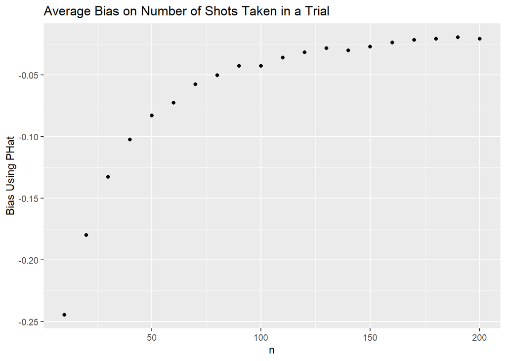

```r
# Bias on Changing n Graph
ggplot(binom.summary.n) +
  geom_point(aes(x = n, y = Avg_bias_p_hat)) +
  ggtitle("Average Bias on Number of Shots Taken in a Trial") +
  ylab("Bias Using PHat")
```

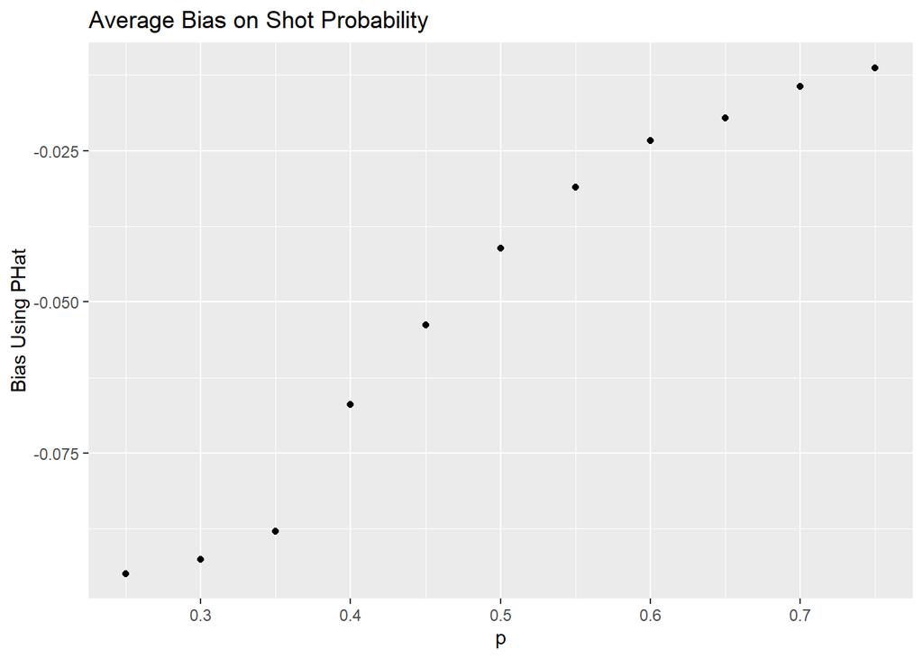

```r
ggplot(binom.summary.p) +
  geom_point(aes(x = pi, y = Avg_bias_p_hat)) +
  ggtitle("Average Bias on Shot Probability") +
  ylab("Bias Using PHat") +
  xlab("p")
```